# Final Report California Housing Data

## Extreme Gradient Boosting vs Linear Regression, California Housing Dataset Analysis

**Matthew Dunbar**  
**IT686 Approaches to Data Analytics for IT Managers, Central Washington University**  
**6/3/2024**

### Discovery

Importing my dataset and libraries. Getting a brief description of what the dataset contains such as attribute information. Having a closer look at the dataset, there is 8 attributes that are all numeric. There seem to be no missing values in this dataset and there are a total of 20,640 data entries.

I created histograms of the attributes to get a better understanding and visualization of the data. Median income looks like a normal distribution with majority of household income condensed around the median salary of somewhere around $25k-$40k per year. As income increases, the amount of earners starts to decline and tails off. There are a few household making a lot more money than the majority. Housing age seems to be pretty diverse as expected, with some houses being built less than 5 years prior, and some that have been built 40+ years ago. It also seems that amount of houses built during the years may be cyclincal in nature due to drop offs in houses being built after peaks in years prior.

Getting a better look at housing prices. What is interesting is that the majority of houses follow a normal distribution around the median price of around just under 200k, but there is a significant number of houses that are way more expensive around 500k. There are actually more houses valued at 500k (luxury outlier), than any other value point on this graph besides houses worth around 160k.

I then created a scatterplot of housing prices relating to their location using the Longitude and Latitude data. The darker the green, the more the housing is worth. Looking at this map one can even see the shape of the state of California. Looking at the density of green areas, one can visibly see the two major metro zones of the Bay Area and the LA/San Diego metros. The closer to these epicenters, the more expensive the houses become.

For the last part of the discovery/visualization phase I created a correlation matrix heatmap. There seems to be only a few attributes potentially correlated with each other. Average Bedrooms is pretty correlated with Average Rooms which makes sense. Bedrooms are often the most common type of room counted, and so if a house has a high number of bedrooms, it has a higher number of rooms total and vice versa. There is a lower correlation with Median Income and Average Rooms. Essentially the higher the income the higher the amount of rooms in that household. Although the correlation between Median Income and Average Bedrooms is not the same. Maybe the amount of rooms that are not a bedroom are increased with rising income, more bathrooms, leisure, other rooms etc.

```python
## Importing my dataset and libraries. Getting a brief description of what the dataset contains such as attribute information.

from sklearn.datasets import fetch_california_housing
import pandas as pd
import seaborn as sns

california_housing = fetch_california_housing(as_frame=True)

print(california_housing.DESCR)
```

```
.. _california_housing_dataset:

California Housing dataset
--------------------------

**Data Set Characteristics:**

    :Number of Instances: 20640

    :Number of Attributes: 8 numeric, predictive attributes and the target

    :Attribute Information:
        - MedInc        median income in block group
        - HouseAge      median house age in block group
        - AveRooms      average number of rooms per household
        - AveBedrms     average number of bedrooms per household
        - Population    block group population
        - AveOccup      average number of household members
        - Latitude      block group latitude
        - Longitude     block group longitude

    :Missing Attribute Values: None

This dataset was obtained from the StatLib repository.
https://www.dcc.fc.up.pt/~ltorgo/Regression/cal_housing.html

The target variable is the median house value for California districts,
expressed in hundreds of thousands of dollars ($100,000).

This dataset was derived from the 1990 U.S. census, using one row per census
block group. A block group is the smallest geographical unit for which the U.S.
Census Bureau publishes sample data (a block group typically has a population
of 600 to 3,000 people).

A household is a group of people residing within a home. Since the average
number of rooms and bedrooms in this dataset are provided per household, these
columns may take surprisingly large values for block groups with few households
and many empty houses, such as vacation resorts.

It can be downloaded/loaded using the
:func:`sklearn.datasets.fetch_california_housing` function.

.. topic:: References

    - Pace, R. Kelley and Ronald Barry, Sparse Spatial Autoregressions,
      Statistics and Probability Letters, 33 (1997) 291-297
```

```python
## Having a closer look at the dataset, there is 8 attributes that are all numeric.
## There seem to be no missing values in this dataset and there are a total of 20,640 data entries.

california_housing.data.head()
```

|  | MedInc | HouseAge | AveRooms | AveBedrms | Population | AveOccup | Latitude | Longitude |
| --- | --- | --- | --- | --- | --- | --- | --- | --- |
| 0 | 8.3252 | 41.0 | 6.984127 | 1.023810 | 322.0 | 2.555556 | 37.88 | -122.23 |
| 1 | 8.3014 | 21.0 | 6.238137 | 0.971880 | 2401.0 | 2.109842 | 37.86 | -122.22 |
| 2 | 7.2574 | 52.0 | 8.288136 | 1.073446 | 496.0 | 2.802260 | 37.85 | -122.24 |
| 3 | 5.6431 | 52.0 | 5.817352 | 1.073059 | 558.0 | 2.547945 | 37.85 | -122.25 |
| 4 | 3.8462 | 52.0 | 6.281853 | 1.081081 | 565.0 | 2.181467 | 37.85 | -122.25 |

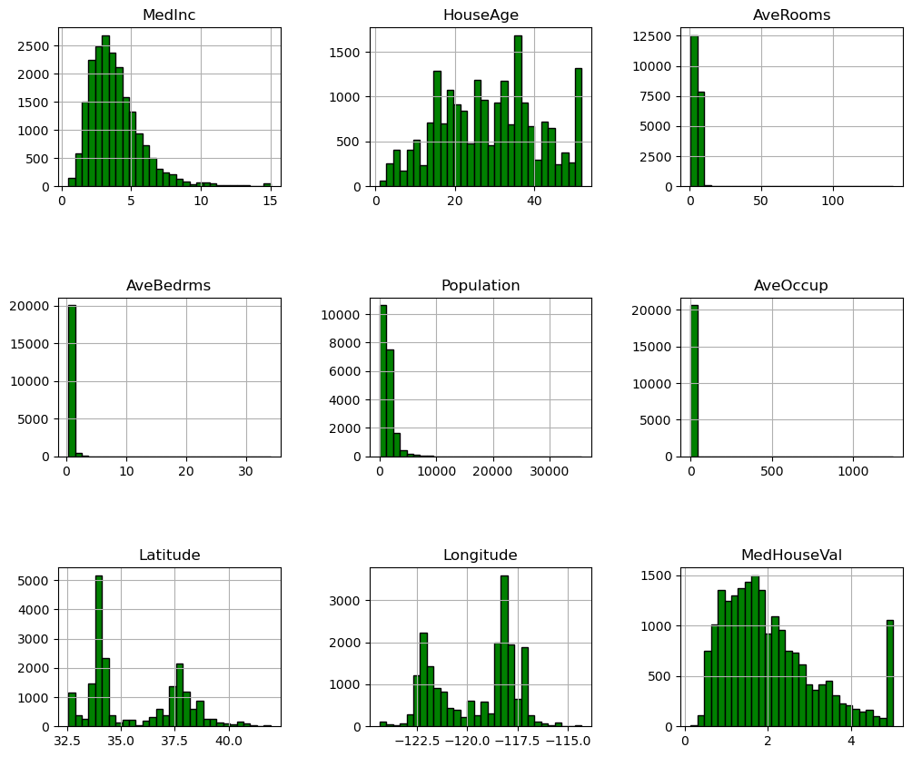

```python
## Creating histograms of the attributes to get a better understanding and visualization of the data.

import matplotlib.pyplot as plt

california_housing.frame.hist(figsize=(12, 10), bins=30, color="green", edgecolor="black")
plt.subplots_adjust(hspace=0.7, wspace=0.4)
```

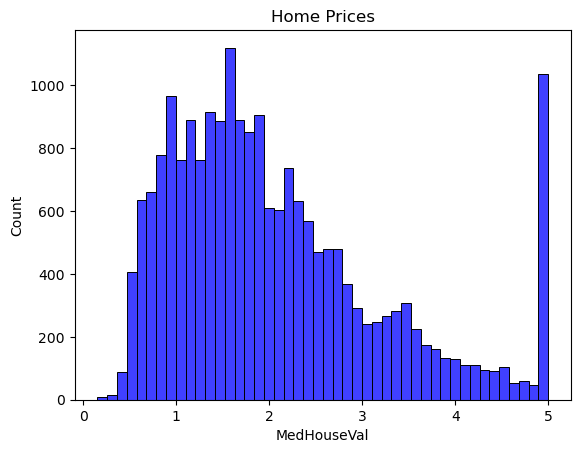

```python
## Getting a better look at housing prices.

Cali_Price = california_housing.target
sns.histplot(Cali_Price, color="blue").set_title('Home Prices')
plt.show()
```

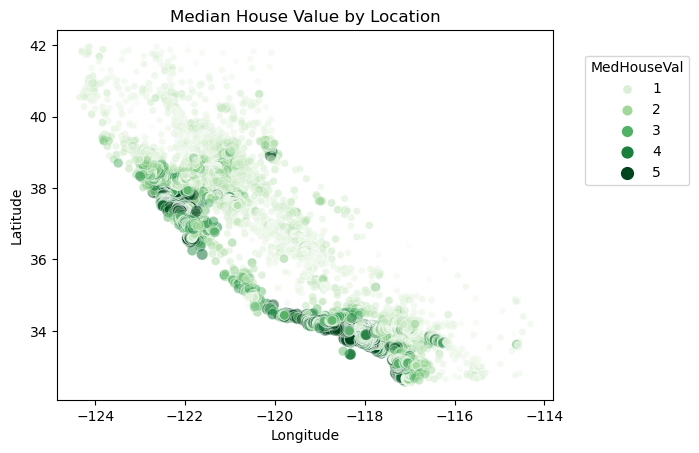

```python
## Looking at housing prices relating to their location using the Longitude and Latitude data.

sns.scatterplot(
    data=california_housing.frame,
    x="Longitude",
    y="Latitude",
    size="MedHouseVal",
    hue="MedHouseVal",
    palette="Greens",
    alpha=0.5,
)
plt.legend(title="MedHouseVal", bbox_to_anchor=(1.05, 0.95), loc="upper left")
_ = plt.title("Median House Value by Location")
```

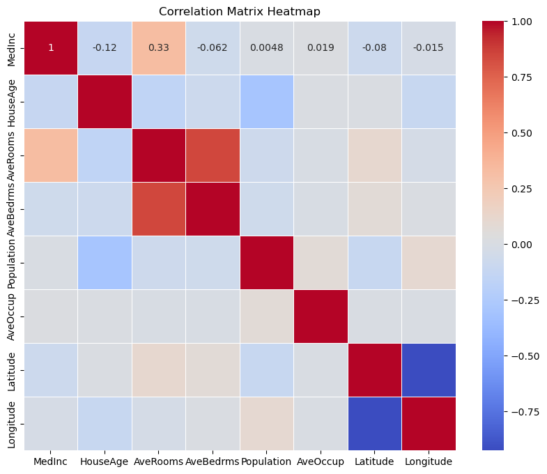

```python
### Creating a Correlational Matrix Heatmap

housing_data = california_housing.data
corr_matrix = housing_data.corr()

plt.figure(figsize=(10, 8))
sns.heatmap(corr_matrix, annot=True, cmap='coolwarm', linewidths=0.5)
plt.title("Correlation Matrix Heatmap")
plt.show()
```

### Model Planning

I am going to try out a few different models to determine which one is most accurate in predicting housing prices for this data. I had to decide which kind of ML technique I should use on this data. I took a look at the differences between Classification and Regressions.

"Classification is the process of finding or discovering a model or function that helps in separating the data into multiple categorical classes i.e. discrete values. In classification, data is categorized under different labels according to some parameters given in the input and then the labels are predicted for the data." (Geeks 2023)

"Regression is the process of finding a model or function for distinguishing the data into continuous real values instead of using classes or discrete values. It can also identify the distribution movement depending on the historical data. Because a regression predictive model predicts a quantity, therefore, the skill of the model must be reported as an error in those predictions." (Geeks 2023)

Since the housing data contains home values and not categorical data, I am going to use Regression Models. The first model is a Gradient Boosting ML Algorithm called extreme gradient boosting, or XGBoost.

```python
# XGBoost Regressor Model

import numpy as np
import pandas as pd
import matplotlib.pyplot as plt
import seaborn as sns
import sklearn.datasets
from sklearn.model_selection import train_test_split
from xgboost import XGBRegressor
from sklearn import metrics

house_dataset = sklearn.datasets.fetch_california_housing()
houseprice_dataframe = pd.DataFrame(house_dataset.data, columns = house_dataset.feature_names)
houseprice_dataframe["Price"] = house_dataset.target
houseprice_dataframe.head()
```

|  | MedInc | HouseAge | AveRooms | AveBedrms | Population | AveOccup | Latitude | Longitude | Price |
| --- | --- | --- | --- | --- | --- | --- | --- | --- | --- |
| 0 | 8.3252 | 41.0 | 6.984127 | 1.023810 | 322.0 | 2.555556 | 37.88 | -122.23 | 4.526 |
| 1 | 8.3014 | 21.0 | 6.238137 | 0.971880 | 2401.0 | 2.109842 | 37.86 | -122.22 | 3.585 |
| 2 | 7.2574 | 52.0 | 8.288136 | 1.073446 | 496.0 | 2.802260 | 37.85 | -122.24 | 3.521 |
| 3 | 5.6431 | 52.0 | 5.817352 | 1.073059 | 558.0 | 2.547945 | 37.85 | -122.25 | 3.413 |
| 4 | 3.8462 | 52.0 | 6.281853 | 1.081081 | 565.0 | 2.181467 | 37.85 | -122.25 | 3.422 |

### Extreme Gradient Boosting Model Building

Training Set - R squared error : 0.943650140819218, Mean Absolute error : 0.1933648700612105

Test Set - R squared error : 0.8338000331788725, Mean Absolute error : 0.3108631800268186

```python
X = houseprice_dataframe.drop(["Price"], axis = 1)
Y = houseprice_dataframe["Price"]
X_train, X_test, Y_train, Y_test = train_test_split(X,Y, test_size = 0.2, random_state = 2)
model = XGBRegressor()
model.fit(X_train, Y_train)
```

```
XGBRegressor(base_score=None, booster=None, callbacks=None,
             colsample_bylevel=None, colsample_bynode=None,
             colsample_bytree=None, device=None, early_stopping_rounds=None,
             enable_categorical=False, eval_metric=None, feature_types=None,
             gamma=None, grow_policy=None, importance_type=None,
             interaction_constraints=None, learning_rate=None, max_bin=None,
             max_cat_threshold=None, max_cat_to_onehot=None,
             max_delta_step=None, max_depth=None, max_leaves=None,
             min_child_weight=None, missing=nan, monotone_constraints=None,
             multi_strategy=None, n_estimators=None, n_jobs=None,
             num_parallel_tree=None, random_state=None, ...)
```

```python
training_data_prediction = model.predict(X_train)
print(training_data_prediction)
```

```
[0.5523039 3.0850039 0.5835302 ... 1.9204227 1.952873  0.6768683]
```

```python
# Predicting and Evaluation of the Training Data
score_1 = metrics.r2_score(Y_train,training_data_prediction)
score_2 = metrics.mean_absolute_error(Y_train,training_data_prediction)
print("R squared error :",score_1)
print("Mean Absolute error :",score_2)
```

```
R squared error : 0.943650140819218
Mean Absolute error : 0.1933648700612105
```

```python
# Predicting and Evaluation of the Testing Data
testing_data_prediction = model.predict(X_test)

score_1 = metrics.r2_score(Y_test, testing_data_prediction)
score_2 = metrics.mean_absolute_error(Y_test, testing_data_prediction)
print("R squared error :",score_1)
print("Mean Absolute error :",score_2)
```

```
R squared error : 0.8338000331788725
Mean Absolute error : 0.3108631800268186
```

### Results

I created a scatterplot of the Y Test data predictions. This is to show predicted values vs actual values, and get a sense of the accuracy of the model.

A point of note is that the model while accurate, seemed to have trouble predicting the houses on the expensive end of the spectrum of around 500k. We noted in the prior discovery process that there were a very large amount of houses for 500k, and that it was a huge outlier compared with the rest of the median home values around 100k-250k. Just something my eye picked up on the right side of the plot (vertical line of houses actually worth $500k, but model predicted lower)

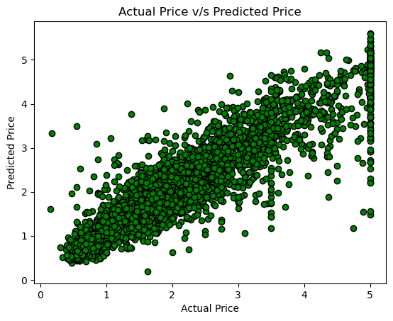

```python
# Plotting the Predicted Price vs the Actual Price

plt.scatter(Y_test, testing_data_prediction, color='green', edgecolor="black")
plt.xlabel("Actual Price")
plt.ylabel("Predicted Price")
plt.title("Actual Price v/s Predicted Price")
plt.show()
```

### Linear Regression Model Building

Building a different model to compare against the XGBoost model. This way I can decide which model was more accurate and should perform better using new data going forward. XGBoost is an advanced learning algorithm, and I wanted to compare how much more it would perform than a simpler model. I decided to go with a very common type of model called Linear Regression. Linear Regression is a simple well known algorithm in statistics and machine learning.

"Linear regression has been around for more than 200 years and has been extensively studied. It is a fast and simple technique and a good first algorithm to try. The representation of linear regression is an equation that describes a line that best fits the relationship between the input variables (x) and the output variables (y), by finding specific weightings for the input variables called coefficients (B)." (Builtin 2024)

I imported all the necessary libraries for performing the linear regression.

```python
import pandas as pd
import numpy as np
from sklearn.datasets import fetch_california_housing
import matplotlib.pyplot as plt
from pandas.plotting import scatter_matrix
from sklearn.metrics import r2_score
from sklearn.linear_model import LinearRegression
from sklearn.pipeline import Pipeline
from sklearn.preprocessing import StandardScaler
from sklearn.model_selection import train_test_split
from sklearn.metrics import r2_score

housing = fetch_california_housing(as_frame=True)
housing = housing.frame
housing.head()

X = housing.iloc[:,:-1]
y = housing.iloc[:,-1]
X_train, X_test, y_train, y_test = train_test_split(X, y, test_size=0.2, random_state=42)

regression_pipeline = Pipeline([
    ('scaler', StandardScaler()),
    ('regressor', LinearRegression())
])
regression_pipeline.fit(X_train,y_train)

y_pred = regression_pipeline.predict(X_test)
r2_score( y_test, y_pred)
```

```
0.5757877060324508
```

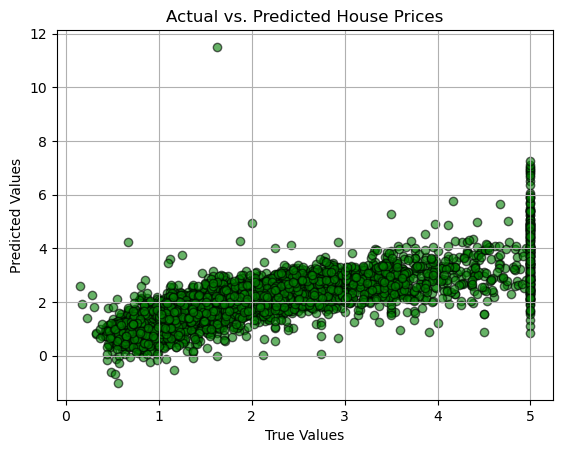

```python
# Scatterplot of Actual vs. Predicted Values

plt.scatter(y_test, y_pred, color='green', edgecolor="black", alpha=0.6)
plt.xlabel('True Values')
plt.ylabel('Predicted Values')
plt.title('Actual vs. Predicted House Prices')
plt.grid(True)
plt.show()
```

```python
# Calculating the R-squared score for the Linear Regression Model
r2 = r2_score(y_test, y_pred)
print(f'R-squared score: {r2:.2f}')
```

```
R-squared score: 0.58
```

### Results

The Linear Regression model was only able to get an R-squared score of around 58%. This was compared to the XGBoost model of 83%. The Gradient Boosting method was significantly more accurate of a model to predict housing prices than a simpler model such a Linear Regression.

### Operationalization

The XGBoost model would be a pretty good choice in model for predicting housing prices. This could be used in companies like Zillow or Redfin in predicting housing prices given certain characteristics or attributes. Either of these companies would be better off predicting values of home prices using a gradient boosting model rather than a simple linear regression. I think this model would perform pretty well to incoming new data, and can be retrained with current or changing market conditions data.

### References

McKinney, W. (2022). *Python for Data Analysis* (3rd ed.). O'Reilly Media.

Geeks for Geeks, 2023. Classification vs Regression in Machine Learning. https://www.geeksforgeeks.org/ml-classification-vs-regression/

Builtin. James, Le. 2024. The Top 10 Machine Learning Algorithms to Know. https://builtin.com/data-science/tour-top-10-algorithms-machine-learning-newbies